# Data Analysis Report: Power Generation from Wind Turbines

STAT 420, Summer 2023, David Luo, Haribansha Timalsina, Jason Sim, Rohan Tuli

2023-08-04

## 0.1 Introduction

**Modelling Power Generation from Wind Turbines**

Given the trend and focus of countries around the world shifting towards green energy, we hope to model factors in power generation from wind turbines to make predictions. To do so, we will be using data from SCADA (Supervisory Control and Data Acquisition) systems. These computer-based systems are typically located within the wind farm itself and acts as data collectors, gathering information from individual turbines and then storing the data as historical records. By using this data to understand the key variables in determining energy output, we would in essence be simulating what it would be like to be a wind farm operator trying to make informed decisions regarding dispatch, maintenance activities, and other operational aspects.

The remainder of the report is divided into four sections: methods, results, discussion, and appendix. In methods, we will report our approach to modelling and the R code utilized to generate our results. The results section will contain numerical and graphical summaries of our model results. The discussion section will tie information from the previous three sections together, covering the primary statistical themes and discoveries, and synthesizing a conclusion from our analysis. Finally, the appendix will contain auxiliary charts and clarifications.

## 0.2 Methods

This section will primarily contain code and text detailing the end-to-end model process, starting from data cleaning all the way to final model selection. Graphs relating to the final model will be presented in the results section.

**Data Cleaning and Pre-Processing**

```r
library(data.table)
library(psych)
library(knitr)
library(faraway)
features <- read.csv("data/features.csv")
power <- read.csv("data/power.csv")
data <- merge(features,power,by = "Timestamp")
```

Given that there are 77 features, our initial focus is to gain a high-level understanding of the predictors, including their types and descriptive statistics. However, before proceeding, we need to sanitize the data.

To keep things simple, we’ll use mean imputation while being cautious about data leakage. Though straightforward, imputing with the mean does not preserve relationships between variables and may lead to underestimating standard errors, potentially causing Type 1 errors in the future. Ideally, we would use more sophisticated methods like PCA for imputation, but this goes beyond the scope of our current class.

```r
# This chunk defines functions to be used

#'Function to do mean imputation
#'@param x dataframe of predictor variables
#'@returns processed dataframe with mean imputed values
mean_imputation <- function(x){
  df <- data.frame(x)
  numeric_columns = sapply(df, is.numeric)
  for (col in names(x)[numeric_columns]) {
    df[is.na(df[, col]), col]   = 99999
    df[df[, col] == 99999, col] <- mean(
      df[df[, col] != 99999, col],na.rm = TRUE)
  }
  return (df)
}

#'Function split the data into training and test sets
#'@param x dataframe of predictor variables
#'@param test_size float representing the proportion of our dataset for testing
#'@returns a list containing train and test data
train_test_split <- function(x, test_size = 0.20){
  set.seed(42)
  indices <- sample(1:nrow(x),nrow(x) * test_size)
  train <-x[-indices,]
  test  <- x[indices,]
  return (list(train, test))
}
```

```r
# Split our data and preprocess with mean imputation
train_test_data <- train_test_split(x = data, test_size = 0.20)
train_data <- mean_imputation(train_test_data[[1]])
test_data  <- mean_imputation(train_test_data[[2]])
```

**Addressing Collinearity**

Now that our data is cleaned to a certain extent, we can examine it. Table 3 in the appendix displays the types of data we have, where all are numeric except for the “Timestamp” feature. Table 4 presents a truncated table of pairwise correlations, focusing on variable pairs with absolute correlations greater than 0.90. Using this correlation table is more concise than a pairs plot, considering the number of predictors. Additionally, we only consider the magnitude of correlations as the sign is irrelevant when identifying collinearity. We’ll simply remove variables that have correlations greater than 0.50 to be stringent.

```r
#'Function to show all pairwise correlations
#'@param cmat correlation matrix
#'@returns a dataframe showing pairwise correlations
flattenCorrMatrix <- function(cmat) {
  ut <- upper.tri(cmat)
  data.frame(
    Predictor1 = rownames(cmat)[row(cmat)[ut]],
    Predictor2 = rownames(cmat)[col(cmat)[ut]],
    AbsCorrelation  = (cmat)[ut])
}

# Flattten upper triangle of correlation matrix into a dataframe with two columns
sub <- subset(train_data, select = -c(Timestamp,Power.kW.))
m <- abs(round(as.data.frame(cor(sub, method = "pearson")),2))
pairwise_corr <- flattenCorrMatrix(m)

# Flag High Correlation features for later removal
pairwise_corr <- pairwise_corr[pairwise_corr$AbsCorrelation > 0.50,]
pairwise_corr <- pairwise_corr[order(pairwise_corr$AbsCorrelation, decreasing=TRUE),]
```

We could also try to identify collinearity by looking for variables with Variance Inflation Factors greater than 5 in a simple additive model that utilizes all the predictors. Table 5 shows the variance inflation factors over 5.

```r
model <- lm(Power.kW. ~ . - Timestamp, data = train_data)
vifs <- sort(faraway::vif(model),decreasing = TRUE)
vif_df <- as.data.frame(vifs[1:5])
colnames(vif_df) <- c("VIF")
```

```r
# Remove high VIF and high correlation features
feature_names <- colnames(train_data)
high_corr_features <- unique(pairwise_corr$Predictor1)
selected_features <- feature_names[!(feature_names %in% high_corr_features)]
processed_train_data <- train_data[,selected_features]
processed_test_data <- test_data[,selected_features]
```

**Model Creation and Selection**

Our model selection process will be iterative, first starting with a simple model and then considering additional changes to reach a final chosen model.

**A Simple Additive Model**

We first start with a simple model utilizing all of the predictor variables. We then apply Backwards AIC Search to select a smaller model. Once we have both, we can utilize ANOVA to determine whether the difference in predictors is significant.

```r
naive_full_add <- lm(Power.kW. ~ . - Timestamp,
  data = data.frame(processed_train_data))

# Backwards AIC to select Model
selected <- step(naive_full_add,direction = "backward",trace = 0)

# Select model via ANOVA
p_val <- anova(selected,naive_full_add)[2,"Pr(>F)"]
if(p_val < 0.05){
  selected <- naive_full_add
}
```

With ANOVA, we fail to reject the null hypothesis that any of the larger model’s additional predictors are significant. Thus, we choose the smaller model. In Table 7, we can see the features selected and their statistics.

**An Improved Model: Data Augmentation and Response Transformation**

Now that we have a benchmark to improve one, let’s consider additional predictors. One important set of predictors not included in the current dataset are seasonal effects. It’s reasonable to assume that the times of day or seasons of the year could influence wind patterns.

```r
augmented_train_data <- data.frame(processed_train_data)
augmented_test_data  <- data.frame(processed_test_data)

#'Function add seasonal predictors
#'@param dataframe
#'@returns a dataframe with seasonal predictors added
add_seasonal_predictors <- function(dataframe){
  dates <- as.POSIXlt(dataframe$Timestamp,
                    format="%Y-%m-%d %H:%M:%S")
  moy <- as.numeric(format(as.Date(dates,format="%Y-%m-%d"), format = "%m"))
  tod <- as.numeric(format(as.POSIXct(dates), format = "%H"))

  moy[moy %in% list(12,1,2)] <- "Winter"
  moy[moy %in% list(3,4,5)]  <- "Spring"
  moy[moy %in% list(6,7,8)]  <- "Summer"
  moy[moy %in% list(9,10,11)]<- "Fall"

  tod[tod %in% list(0,1,2,3,4,5)]    <- "Early Morning"
  tod[tod %in% list(6,7,8,9,10,11)]  <- "Morning"
  tod[tod %in% list(12,13,14,15,16,17)] <- "Afternoon"
  tod[tod %in% list(18,19,20,21,22,23)] <- "Evening"
  dataframe["MOY"] = as.factor(moy)
  dataframe["TOD"] = as.factor(tod)
  return (dataframe)
}

augmented_train_data <- add_seasonal_predictors(augmented_train_data)
augmented_test_data  <- add_seasonal_predictors(augmented_test_data)

# Hardcode since there are 11 NA values have time hour 2
augmented_train_data$TOD[is.na(augmented_train_data$TOD)] <- "Early Morning"
```

Considering that we are working with time series data, is is possible that our response variable exhibits autocorrelation. This would violate the independence assumption for our model if not accounted for. We can check by simply regressing Power.kW. against its lagged values and look their significances in Table 8. Since the coefficients are significant, we can introduce the lagged values as predictors.

```r
datacopy <- data.frame(data)
for (i in 1:5){
  col_name <- paste("Power.kW.Lag",toString(i))
  datacopy[,col_name] <- shift(data$Power.kW.,i)

  # merge into data a columns of lag i Power.kW.

  augmented_train_data <- merge(augmented_train_data,datacopy[,c("Timestamp",col_name)],by = "Timestamp")

  augmented_test_data <- merge(augmented_test_data,datacopy[,c("Timestamp",col_name)],by = "Timestamp")

  # mean impute with mean value of training set Power.kW.
  # There will at most be 5 NA values anyways so it should not affect the modelling
  # given there are tens of thousands of data points.

  augmented_train_data[,col_name] <- replace(augmented_train_data[,col_name],is.na(augmented_train_data[,col_name]),mean(augmented_train_data$Power.kW.))

  augmented_test_data[,col_name] <- replace(augmented_test_data[,col_name],is.na(augmented_test_data[,col_name]),mean(processed_train_data$Power.kW.))

}
```

We can also sanitize the data further, forcing some continuous variables which should be discrete to factors. Turbine State looks to be a factor, so we force it to 1 and not 1. The same applies to State and Fault.

```r
# Force below features into factors
augmented_train_data$Turbine.State <- as.factor(augmented_train_data$Turbine.State==1)
augmented_train_data$State.and.Fault <- as.factor(augmented_train_data$State.and.Fault==1)

augmented_test_data$Turbine.State <- as.factor(augmented_test_data$Turbine.State==1)
augmented_test_data$State.and.Fault <- as.factor(augmented_test_data$State.and.Fault==1)
```

There also seems to be a lot of 0 to negative readings for power. We can try to see what may be causing the 0 to negative readings by filtering the dataset on that criteria. We can create the two tables (Table 9 and Table 10) to help identify what’s different when there are 0 to negative readings for power.

It seems that the median reading for Moment D Direction is negative when power is negative, and vice versa. The opposite is true for Moment Q Filtered. We’ll try adding factor variables that address this.

```r
augmented_train_data$Moment.D.DirectionF <- as.factor(augmented_train_data$Moment.D.Direction < 0)
augmented_test_data$Moment.D.DirectionF <-  as.factor(augmented_test_data$Moment.D.Direction < 0)

augmented_train_data$Moment.Q.FillteredF <- as.factor(augmented_train_data$Moment.Q.Filltered > 0)
augmented_test_data$Moment.Q.FillteredF <- as.factor(augmented_test_data$Moment.Q.Filltered > 0)
```

```r
# Remove Timestamp for later convinience
augmented_train_data <- subset(augmented_train_data, select = -c(Timestamp))
augmented_test_data <- subset(augmented_test_data, select = -c(Timestamp))
```

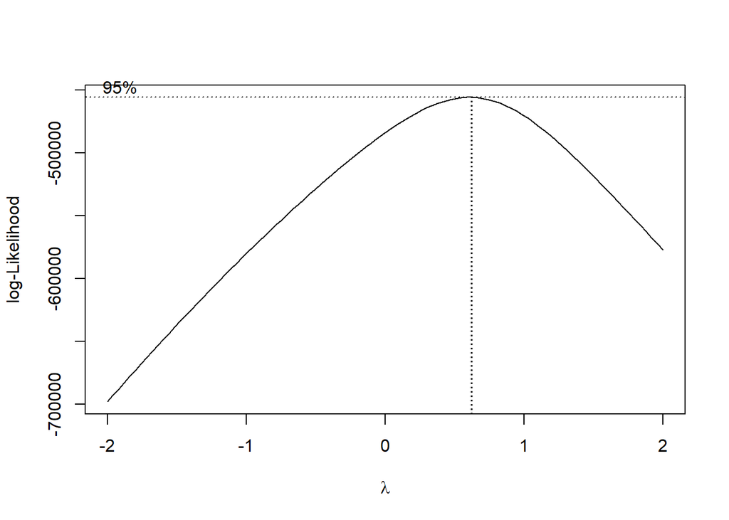

```r
# Find the optimal lambda
const <- 2*abs(min(augmented_train_data$Power.kW.)) + 100

b <- MASS::boxcox(lm(Power.kW.+ const ~ . + MOY:TOD  ,data = data.frame(augmented_train_data)))
```

```r
lambda <- b$x[which.max(b$y)]

# Fit Model
transformed <- lm( ((Power.kW. + const)^lambda - 1)/lambda ~ . ,
data <- data.frame(augmented_train_data) )
transformselected <- step(transformed, direction = "backward", trace=0)
```

We can then use ANOVA once again to compare the larger model with the nested model. Here we fail to reject the null hypothesis again, and thus choose the smaller model again. The coefficients and statistics of the final model are presented in Table 11.

```r
# Select model via ANOVA
p_val <- anova(transformselected,transformed)[2,"Pr(>F)"]
if(p_val < 0.05){
  transformselected <- transformed
}
```

## 0.3 Results

**Diagnostics**

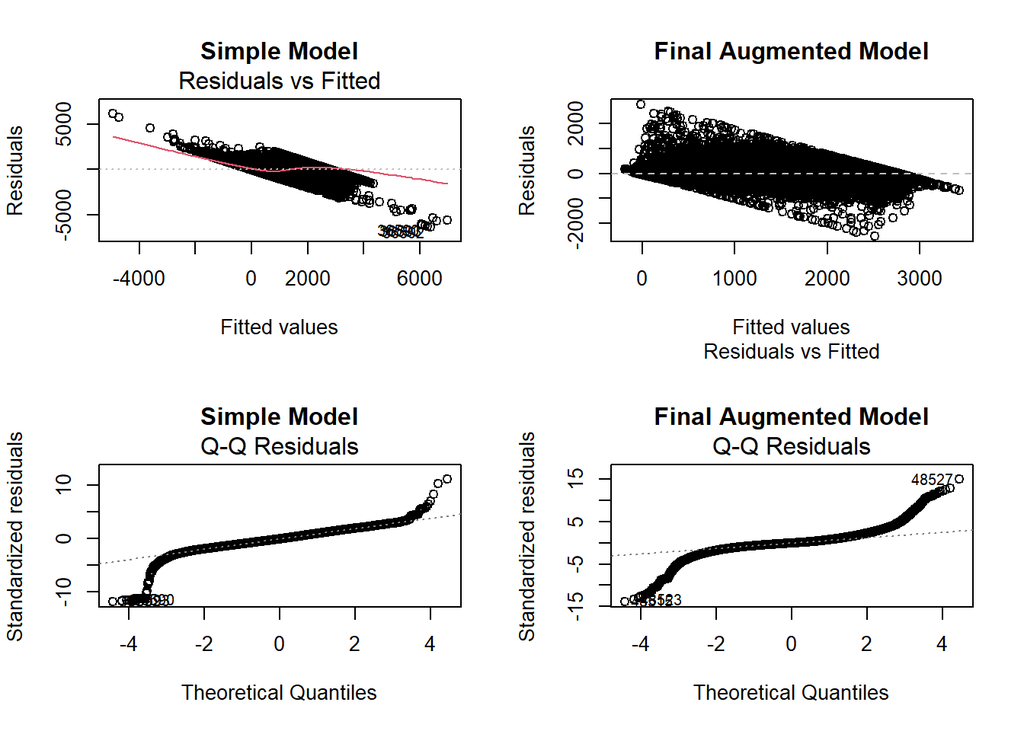

Figure 1: Dianostic Plots

**Comparison and Performance**

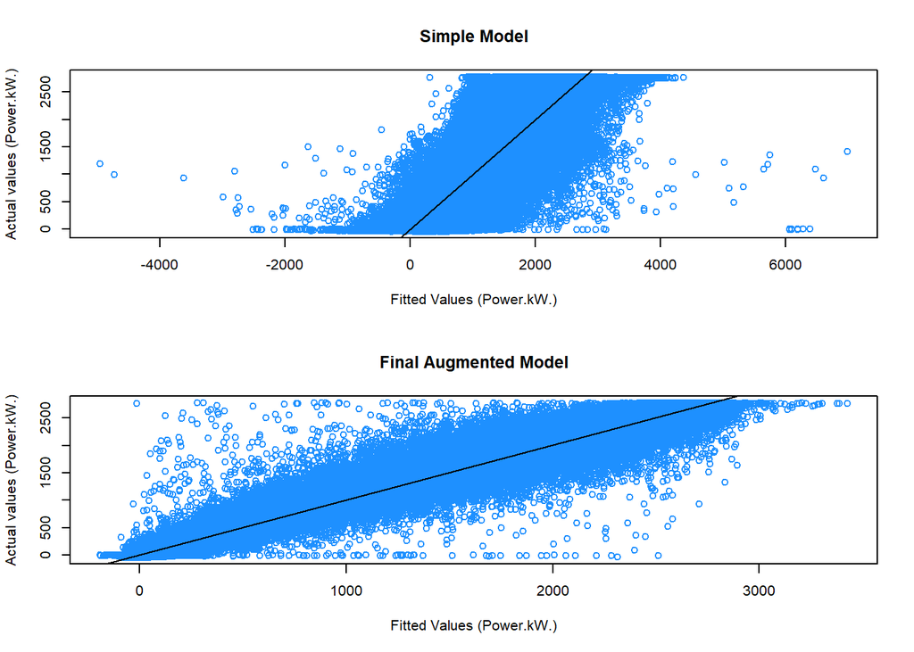

Figure 2: Actual vs. Fitted Values (Power.kW.)

Table 1: Comparison of Models

|  | Simple Model | Final Augmented Data Model |
| --- | --- | --- |
| Number of Beta Parameters | 19.0000000 | 36.0000000 |
| Significant Beta Parameters (p<0.05) | 19.0000000 | 34.0000000 |
| Adjusted R Squared | 0.7385716 | 0.9700354 |
| Train LOOCV RMSE | 552.4102008 | 13.1835072 |
| Test RMSE | 545.5516409 | 194.1991100 |
| Test Median Percentage Error | 0.4543138 | 0.1510198 |

*Note: Train LOOCV for the final augmented model uses residuals from transformed data.

Table 2: Shared Features Between Both Models

| Shared.Predictors |
| --- |
| Temperature.Trafo.2 |
| Moment.D.Direction |
| Power.Factor |
| Nacelle.Position_Degree |
| Hydraulic.Prepressure |
| Angle.Rotor.Position |
| Pitch.Offset.Tower.Feedback |
| Internal.Power.Limit |
| Particle.Counter |
| Temperature.Ambient |
| Nacelle.Revolution |
| Tower.Deflection |
| Pitch.Offset.3.Asymmetric.Load.Controller |
| Wind.Deviation.10.seconds |
| Moment.Q.Filltered |
| Proxy.Sensor_Degree.315 |

## 0.4 Discussion

**Diagnostics**

In the results section, when we look at residuals against the fitted values for both of the models, we can clearly see that there is some linear relationship between them for each model. Possible causes for this are the fact that there there seems to be many low to negative as well as a ceiling in actual power values the models were not able to capture. To address this, two steps were taken: lagged response values were included as predictors, and a Box-Cox transform was applied to the response variable.

These actions improved the situation, as the harsh linear pattern observed in the simple model’s plot softened in the final augmented model’s plot, with residuals more centered around zero along the fitted values. However, the normality assumption may have been further violated, as evidenced by the augmented model’s Q-Q plot showing fatter tails compared to the simple model.

**Model Comparison and Performance**

The Fitted vs Actual plots clearly show that the augmented model fits the data better than the simple model. Firstly, the range of predictions closely aligns with the actual Power.kW values, unlike the simple model’s predictions, which include implausible extreme, negative numbers. Secondly, the points on the augmented model plot more closely follow the 45-degree line, while the simple model’s points exhibit a slight upward curve. This suggests that the Box-Cox transform was beneficial.

In the Table comparing metrics, though the models share a lot of features, as shown in Table 2, the final augmented model includes more significant features. Among these significant features are the ones added in the augmentation process, including seasonality, the new factor variables, and the lagged response variables. The augmented model outperforms the simple model significantly when looking at Table 1. The adjusted R-Squared for the simple model is 0.7386, whereas the augmented model achieves 0.97, indicating better explanation of the variation in Power.kW. Additionally, the test RMSE and median percentage error for the augmented model are considerably smaller than those of the simple model.

In conclusion, our final model excels in two aspects: explaining a substantial amount of variation in power generation and making accurate predictions (within 15%) for given periods based on a cross-section of measurements. The increased performance is due additional predictors added, as well as the Box-Cox transformation on the response variable. From this we learned that in addition to the individual components of a wind turbine, the season, time of day, and past power levels affects current power generation.

### 0.4.1 Appendix

**Citations**

Please download data and extract into a directory named “data” contained in the same parent directory as the .Rmd file.

- Data Source: https://www.kaggle.com/datasets/psycon/wind-turbine-energy-kw-generation-data?select=feature_units.csv
- SCADA Description: https://www.emerson.com/en-us/automation/control-and-safety-systems/distributed-control-systems-dcs/ovation-distributed-control-system/wind-turbine-controls/wind-turbine-scada-system

**Tables**

Table 3: Summary of Data

|  | vars | n | mean | sd | median | trimmed | mad | min | max | range | skew | kurtosis | se |
| --- | --- | --- | --- | --- | --- | --- | --- | --- | --- | --- | --- | --- | --- |
| Temperature.Trafo.2 | 1 | 109384 | 65.4608550 | 11.6995343 | 63.1699982 | 64.3828980 | 9.1476393 | 15.0000000 | 1.310000e+02 | 1.160000e+02 | 1.3216226 | 3.7786682 | 0.0353746 |
| Moment.D.Direction | 2 | 109384 | 123.0387926 | 185.9369052 | 127.9692192 | 116.8047961 | 173.9999220 | -3001.3615723 | 1.446542e+03 | 4.447903e+03 | -1.5741759 | 24.3388373 | 0.5621972 |
| Power.Factor | 3 | 109384 | 0.1801358 | 0.8244009 | 0.1801358 | 0.2245557 | 1.2007047 | -1.0000000 | 1.000000e+00 | 2.000000e+00 | -0.2894120 | -1.6119447 | 0.0024927 |
| Nacelle.Position_Degree | 4 | 109384 | 219.8417048 | 128.9815515 | 219.8417048 | 229.7841823 | 182.5944885 | 0.0000000 | 3.599983e+02 | 3.599983e+02 | -0.4254021 | -1.2232642 | 0.3899875 |
| Hydraulic.Prepressure | 5 | 109384 | 75.8417728 | 6.1772955 | 75.8241158 | 75.7054176 | 4.7005689 | -25.0000000 | 1.022717e+02 | 1.272717e+02 | -1.3277556 | 23.4588745 | 0.0186776 |
| Angle.Rotor.Position | 6 | 109384 | 176.6451668 | 62.7264659 | 179.5524597 | 179.2843088 | 1.8369504 | 0.0218020 | 9.990000e+02 | 9.989782e+02 | 8.8757738 | 118.7109216 | 0.1896592 |
| Pitch.Offset.Tower.Feedback | 7 | 109384 | 0.0000677 | 0.0006304 | 0.0000000 | 0.0000248 | 0.0000000 | -0.0181360 | 9.408000e-03 | 2.754400e-02 | 1.4879887 | 32.9724633 | 0.0000019 |
| Line.Frequency | 8 | 109384 | 49.9655784 | 1.1216191 | 49.9925156 | 49.9919395 | 0.0145520 | 0.0000000 | 5.029235e+01 | 5.029235e+01 | -43.6598087 | 1918.7791464 | 0.0033913 |
| Internal.Power.Limit | 9 | 109384 | 2772.5154733 | 89.0141999 | 2780.0000000 | 2780.0000000 | 0.0000000 | 1595.1650391 | 2.780000e+03 | 1.184835e+03 | -12.5953776 | 157.7716130 | 0.2691426 |
| Particle.Counter | 10 | 109384 | 0.2602850 | 0.4302712 | 0.0000000 | 0.2003590 | 0.0000000 | 0.0000000 | 1.000000e+00 | 1.000000e+00 | 1.1142403 | -0.7184769 | 0.0013010 |
| Torque.Offset.Tower.Feedback | 11 | 109384 | -0.0016953 | 0.3089139 | 0.0000000 | -0.0011712 | 0.2020782 | -9.2706203 | 1.025045e+01 | 1.952107e+01 | 0.9109944 | 55.4913647 | 0.0009340 |
| External.Power.Limit | 12 | 109384 | 3299.8278610 | 22.2017084 | 3300.0000000 | 3300.0000000 | 0.0000000 | 0.0000000 | 3.300000e+03 | 3.300000e+03 | -143.9135446 | 20980.9045437 | 0.0671289 |
| Blade.3.Actual.Value_Angle.B | 13 | 109384 | 0.0310816 | 17.5032810 | 0.0000000 | 0.0000000 | 0.0000000 | -2116.3352051 | 5.388166e+03 | 7.504501e+03 | 250.5271212 | 84047.0682663 | 0.0529228 |
| Tower.Accelaration.Lateral.Raw | 14 | 109384 | -0.3717886 | 111.9521825 | -2.0326324 | -1.9841205 | 0.4515462 | -8.6866894 | 1.191771e+04 | 1.192640e+04 | 103.0452957 | 10824.9844598 | 0.3384977 |
| Temperature.Ambient | 15 | 109384 | 16.5222201 | 8.8514569 | 16.5222201 | 16.6511908 | 9.3222617 | -273.0000000 | 4.067167e+01 | 3.136717e+02 | -6.7956079 | 218.5979893 | 0.0267632 |
| Nacelle.Revolution | 16 | 109384 | 0.1615460 | 0.6481883 | 0.1834444 | 0.1730708 | 0.6515684 | -1.8111111 | 1.789551e+00 | 3.600662e+00 | -0.1693816 | -0.0874084 | 0.0019599 |
| Tower.Deflection | 17 | 109384 | 3156.6053180 | 50.9045349 | 3175.0000000 | 3168.2206552 | 8.8956000 | 2952.0000000 | 3.188000e+03 | 2.360000e+02 | -3.3930825 | 10.8397130 | 0.1539145 |
| Pitch.Offset.3.Asymmetric.Load.Controller | 18 | 109384 | -0.0004854 | 0.0097425 | 0.0000000 | -0.0000714 | 0.0000000 | -0.5191507 | 4.369220e-02 | 5.628429e-01 | -30.5477978 | 1149.3353034 | 0.0000295 |
| Wind.Deviation.10.seconds | 19 | 109384 | -0.0020413 | 16.9308172 | -0.8450000 | -0.8466839 | 1.6802800 | -180.0000000 | 1.670533e+02 | 3.470533e+02 | 1.1722894 | 30.3218929 | 0.0511919 |
| State.and.Fault* | 20 | 109384 | 1.0520551 | 0.2221393 | 1.0000000 | 1.0000000 | 0.0000000 | 1.0000000 | 2.000000e+00 | 1.000000e+00 | 4.0329722 | 14.2649949 | 0.0006717 |
| Moment.Q.Filltered | 21 | 109384 | -9.5228716 | 53.2268170 | -9.5228716 | -8.3708407 | 39.0704681 | -1286.7078857 | 1.323435e+03 | 2.610142e+03 | -0.9341646 | 40.9328388 | 0.1609361 |
| Turbine.State* | 22 | 109384 | 1.7780663 | 0.4155487 | 2.0000000 | 1.8475796 | 0.0000000 | 1.0000000 | 2.000000e+00 | 1.000000e+00 | -1.3382966 | -0.2089641 | 0.0012564 |
| Proxy.Sensor_Degree.315 | 23 | 109384 | 5.8045158 | 0.1163143 | 5.8016820 | 5.8060959 | 0.0972496 | -0.2388000 | 6.231746e+00 | 6.470546e+00 | -27.0507243 | 1399.4211343 | 0.0003517 |
| Power.kW. | 24 | 109384 | 1139.0320350 | 1079.1343014 | 779.4133301 | 1081.9325717 | 1184.1773251 | -48.5966682 | 2.779423e+03 | 2.828020e+03 | 0.3830356 | -1.4843376 | 3.2628612 |
| MOY* | 25 | 109384 | 2.5842171 | 1.0587809 | 3.0000000 | 2.6052704 | 1.4826000 | 1.0000000 | 4.000000e+00 | 3.000000e+00 | -0.0658980 | -1.2204354 | 0.0032013 |
| TOD* | 26 | 109384 | 2.5021850 | 1.1170717 | 3.0000000 | 2.5027312 | 1.4826000 | 1.0000000 | 4.000000e+00 | 3.000000e+00 | -0.0020131 | -1.3578126 | 0.0033776 |
| Power.kW.Lag.1 | 27 | 109384 | 1138.9104013 | 1079.1343993 | 777.4308472 | 1081.7824470 | 1181.4135377 | -48.5966682 | 2.779423e+03 | 2.828020e+03 | 0.3827936 | -1.4847349 | 3.2628615 |
| Power.kW.Lag.2 | 28 | 109384 | 1138.7470281 | 1079.0121184 | 777.8758240 | 1081.5780824 | 1182.0263097 | -48.5966682 | 2.779423e+03 | 2.828020e+03 | 0.3830349 | -1.4843476 | 3.2624917 |
| Power.kW.Lag.3 | 29 | 109384 | 1138.3898164 | 1079.2603453 | 775.4841614 | 1081.1335164 | 1178.5137907 | -48.5966682 | 2.779423e+03 | 2.828020e+03 | 0.3842947 | -1.4839714 | 3.2632423 |
| Power.kW.Lag.4 | 30 | 109384 | 1138.0385747 | 1078.9324962 | 774.9066467 | 1080.6938963 | 1177.5797299 | -47.6916656 | 2.779423e+03 | 2.827115e+03 | 0.3851498 | -1.4825858 | 3.2622510 |
| Power.kW.Lag.5 | 31 | 109384 | 1138.1977858 | 1079.1436589 | 775.1941833 | 1080.8930847 | 1178.0591583 | -48.5966682 | 2.779423e+03 | 2.828020e+03 | 0.3848009 | -1.4831303 | 3.2628895 |
| Moment.D.DirectionF* | 32 | 109384 | 1.2737329 | 0.4458756 | 1.0000000 | 1.2171687 | 0.0000000 | 1.0000000 | 2.000000e+00 | 1.000000e+00 | 1.0149245 | -0.9699370 | 0.0013481 |
| Moment.Q.FillteredF* | 33 | 109384 | 1.3932019 | 0.4884633 | 1.0000000 | 1.3665036 | 0.0000000 | 1.0000000 | 2.000000e+00 | 1.000000e+00 | 0.4372779 | -1.8088046 | 0.0014769 |

Table 4: Variables with Pairwise Correlation Greater than 0.90

|  | Predictor1 | Predictor2 | AbsCorrelation |
| --- | --- | --- | --- |
| 461 | Voltage.A.N | Voltage.B.N | 0.99 |
| 55 | Gearbox_T3_Intermediate_Speed_Shaft_Temperature | Gearbox_Oil.1_Temperature | 0.97 |
| 190 | Moment.D.Filtered | Moment.D.Direction | 0.97 |
| 377 | Voltage.A.N | Voltage.C.N | 0.97 |
| 463 | Voltage.C.N | Voltage.B.N | 0.97 |
| 1525 | Pitch.Offset.2.Asymmetric.Load.Controller | Pitch.Offset.1.Asymmetric.Load.Controller | 0.97 |
| 2346 | Blade.2.Set.Value_Degree | Pitch.Demand.Baseline_Degree | 0.97 |
| 2414 | Blade.2.Set.Value_Degree | Blade.1.Set.Value_Degree | 0.97 |
| 2483 | Blade.2.Set.Value_Degree | Blade.3.Set.Value_Degree | 0.97 |
| 2484 | Pitch.Demand.Baseline_Degree | Blade.3.Set.Value_Degree | 0.97 |
| 3 | Gearbox_T3_High_Speed_Shaft_Temperature | Gearbox_T1_Intermediate_Speed_Shaft_Temperature | 0.96 |
| 12 | Gearbox_T3_High_Speed_Shaft_Temperature | Gearbox_Oil.2_Temperature | 0.96 |
| 13 | Gearbox_T1_Intermediate_Speed_Shaft_Temperature | Gearbox_Oil.2_Temperature | 0.96 |
| 38 | Gearbox_T3_High_Speed_Shaft_Temperature | Gearbox_T3_Intermediate_Speed_Shaft_Temperature | 0.96 |
| 42 | Gearbox_Oil.2_Temperature | Gearbox_T3_Intermediate_Speed_Shaft_Temperature | 0.96 |
| 51 | Gearbox_Oil.2_Temperature | Gearbox_Oil.1_Temperature | 0.96 |
| 59 | Temperature.Gearbox.Bearing.Hollow.Shaft | Gearbox_Oil_Temperature | 0.96 |
| 119 | Converter.Control.Unit.Reactive.Power | Reactive.Power | 0.96 |
| 231 | N.set.1 | Operating.State | 0.96 |
| 270 | Temperature.Shaft.Bearing.1 | Temperature.Shaft.Bearing.2 | 0.96 |
| 595 | Temperature.Battery.Box.3 | Temperature.Battery.Box.2 | 0.96 |
| 629 | Temperature.Battery.Box.3 | Temperature.Battery.Box.1 | 0.96 |
| 630 | Temperature.Battery.Box.2 | Temperature.Battery.Box.1 | 0.96 |
| 2080 | Blade.3.Actual.Value_Angle.A | Scope.CH.4 | 0.96 |
| 2211 | Blade.2.Actual.Value_Angle.A | Blade.1.Actual.Value_Angle.A | 0.96 |
| 2277 | Blade.2.Actual.Value_Angle.A | Blade.2.Set.Value_Degree | 0.96 |
| 2278 | Blade.1.Actual.Value_Angle.A | Blade.2.Set.Value_Degree | 0.96 |
| 2344 | Blade.2.Actual.Value_Angle.A | Pitch.Demand.Baseline_Degree | 0.96 |
| 2345 | Blade.1.Actual.Value_Angle.A | Pitch.Demand.Baseline_Degree | 0.96 |
| 2412 | Blade.2.Actual.Value_Angle.A | Blade.1.Set.Value_Degree | 0.96 |

[output cut: 57 more lines]

Table 5: Variance Inflation Factors Greater Than 5

|  | VIF |
| --- | --- |
| Blade.1.Actual.Value_Angle.B | 8.066432e+06 |
| Blade.3.Actual.Value_Angle.B | 5.427150e+06 |
| Blade.2.Actual.Value_Angle.B | 9.655339e+05 |
| Voltage.B.N | 7.453561e+01 |
| Voltage.A.N | 7.382871e+01 |

Table 6: After Removing Correlated Features

| Reduced Features |
| --- |
| Timestamp |
| Temperature.Trafo.2 |
| Moment.D.Direction |
| Power.Factor |
| Nacelle.Position_Degree |
| Hydraulic.Prepressure |
| Angle.Rotor.Position |
| Pitch.Offset.Tower.Feedback |
| Line.Frequency |
| Internal.Power.Limit |
| Particle.Counter |
| Torque.Offset.Tower.Feedback |
| External.Power.Limit |
| Blade.3.Actual.Value_Angle.B |
| Tower.Accelaration.Lateral.Raw |
| Temperature.Ambient |
| Nacelle.Revolution |
| Tower.Deflection |
| Pitch.Offset.3.Asymmetric.Load.Controller |
| Wind.Deviation.10.seconds |
| State.and.Fault |
| Moment.Q.Filltered |
| Turbine.State |
| Proxy.Sensor_Degree.315 |
| Power.kW. |

Table 7: Selected Model Features

|  | Estimate | Std. Error | t value | Pr(>\|t\|) |
| --- | --- | --- | --- | --- |
| (Intercept) | -2.170591e+03 | 178.7897739 | -12.140464 | 0.00e+00 |
| Temperature.Trafo.2 | 3.838765e+01 | 0.1772729 | 216.545569 | 0.00e+00 |
| Moment.D.Direction | 1.108498e+00 | 0.0114330 | 96.956087 | 0.00e+00 |
| Power.Factor | 3.233590e+02 | 2.3293372 | 138.820186 | 0.00e+00 |
| Nacelle.Position_Degree | 2.854842e-01 | 0.0135730 | 21.033187 | 0.00e+00 |
| Hydraulic.Prepressure | 5.284903e+00 | 0.3071152 | 17.208208 | 0.00e+00 |
| Angle.Rotor.Position | 4.168593e-01 | 0.0293121 | 14.221422 | 0.00e+00 |
| Pitch.Offset.Tower.Feedback | -3.493611e+04 | 2668.1305105 | -13.093854 | 0.00e+00 |
| Internal.Power.Limit | 9.087490e-02 | 0.0189736 | 4.789538 | 1.70e-06 |
| Particle.Counter | -1.912712e+02 | 4.5967331 | -41.610250 | 0.00e+00 |
| Temperature.Ambient | -3.464971e+00 | 0.2336575 | -14.829275 | 0.00e+00 |
| Nacelle.Revolution | 1.155670e+01 | 2.6332657 | 4.388733 | 1.14e-05 |
| Tower.Deflection | 1.747504e+00 | 0.0371521 | 47.036511 | 0.00e+00 |
| Pitch.Offset.3.Asymmetric.Load.Controller | -3.921365e+03 | 172.0450630 | -22.792665 | 0.00e+00 |
| Wind.Deviation.10.seconds | 1.049076e+00 | 0.1008613 | 10.401175 | 0.00e+00 |
| State.and.Fault | -7.682190e-02 | 0.0188538 | -4.074612 | 4.61e-05 |
| Moment.Q.Filltered | -3.912155e+00 | 0.0343141 | -114.010192 | 0.00e+00 |
| Turbine.State | -3.209928e+02 | 2.6093504 | -123.016379 | 0.00e+00 |
| Proxy.Sensor_Degree.315 | -8.945828e+02 | 20.9922784 | -42.614850 | 0.00e+00 |

Table 8: Lagged Power.kW. Coefficients

|  | Estimate | Std. Error | t value | Pr(>\|t\|) |
| --- | --- | --- | --- | --- |
| (Intercept) | 19.3371660 | 0.9468861 | 20.421850 | 0.0000000 |
| shift(Power.kW., 1) | 0.9690275 | 0.0030223 | 320.626092 | 0.0000000 |
| shift(Power.kW., 2) | -0.0633692 | 0.0042092 | -15.054806 | 0.0000000 |
| shift(Power.kW., 3) | 0.0319564 | 0.0042125 | 7.586110 | 0.0000000 |
| shift(Power.kW., 4) | 0.0145409 | 0.0042092 | 3.454513 | 0.0005515 |
| shift(Power.kW., 5) | 0.0308827 | 0.0030223 | 10.218245 | 0.0000000 |

Table 9: Descriptive Stats when Power.kW. > 0

|  | min | mean | median | max |
| --- | --- | --- | --- | --- |
| Temperature.Trafo.2 | 16.0000000 | 66.9957761 | 65.0000000 | 131.0000000 |
| Moment.D.Direction | -508.2739258 | 157.9176840 | 167.0214844 | 1446.5417480 |
| Power.Factor | -1.0000000 | 0.2118171 | 0.9465076 | 1.0000000 |
| Nacelle.Position_Degree | 0.0000000 | 229.8963733 | 250.5700073 | 359.9983215 |
| Hydraulic.Prepressure | 6.0749345 | 76.0445397 | 75.8417728 | 102.2716904 |
| Angle.Rotor.Position | 5.5501571 | 179.7314811 | 179.7694397 | 753.3941650 |
| Pitch.Offset.Tower.Feedback | -0.0181360 | 0.0000818 | 0.0000000 | 0.0094080 |
| Line.Frequency | 0.0000000 | 49.9637044 | 49.9924316 | 50.2923508 |
| Internal.Power.Limit | 1597.8325195 | 2773.0441128 | 2780.0000000 | 2780.0000000 |
| Particle.Counter | 0.0000000 | 0.2640091 | 0.0000000 | 1.0000000 |
| Torque.Offset.Tower.Feedback | -6.3023829 | 0.0002642 | -0.0016953 | 10.2504501 |
| External.Power.Limit | 0.0000000 | 3299.8442207 | 3300.0000000 | 3300.0000000 |
| Blade.3.Actual.Value_Angle.B | 0.0000000 | 0.0011846 | 0.0000000 | 0.0310816 |
| Tower.Accelaration.Lateral.Raw | -8.6866894 | -1.7027704 | -2.0127695 | 255.1254425 |
| Temperature.Ambient | -4.0000000 | 16.4458083 | 16.5222201 | 38.0000000 |
| Nacelle.Revolution | -1.7945648 | 0.1548672 | 0.1815648 | 1.7895509 |
| Tower.Deflection | 2952.0000000 | 3155.9445061 | 3175.0000000 | 3188.0000000 |
| Pitch.Offset.3.Asymmetric.Load.Controller | -0.5191507 | -0.0005885 | 0.0000000 | 0.0436922 |
| Wind.Deviation.10.seconds | -148.8833313 | -0.9546380 | -0.9100000 | 62.8433342 |
| Moment.Q.Filltered | -1286.7078857 | -11.6309457 | -14.6121798 | 1323.4345703 |
| Proxy.Sensor_Degree.315 | 5.2953796 | 5.7867836 | 5.7754412 | 6.2317462 |
| Power.kW. | 0.0016667 | 1394.1854857 | 1271.1566162 | 2779.4233398 |
| Power.kW.Lag 1 | -42.0683327 | 1392.5058835 | 1272.7283936 | 2779.4233398 |
| Power.kW.Lag 2 | -42.0683327 | 1390.4112361 | 1270.9483643 | 2779.4233398 |
| Power.kW.Lag 3 | -42.0683327 | 1388.4094528 | 1267.2099609 | 2779.4233398 |
| Power.kW.Lag 4 | -42.0683327 | 1386.5661591 | 1264.7133789 | 2779.4233398 |
| Power.kW.Lag 5 | -42.0683327 | 1385.1638950 | 1265.0416260 | 2779.4233398 |

Table 10: Descriptive Stats when Power.kW. <= 0

|  | min | mean | median | max |
| --- | --- | --- | --- | --- |
| Temperature.Trafo.2 | 15.0000000 | 58.4727134 | 59.0000000 | 8.863667e+01 |
| Moment.D.Direction | -3001.3615723 | -35.7567492 | -15.8857059 | 3.705329e+02 |
| Power.Factor | -1.0000000 | 0.0358981 | -0.0733848 | 1.000000e+00 |
| Nacelle.Position_Degree | 0.0000000 | 174.0651199 | 169.3266602 | 3.599983e+02 |
| Hydraulic.Prepressure | -25.0000000 | 74.9186218 | 75.5692749 | 9.783698e+01 |
| Angle.Rotor.Position | 0.0218020 | 162.5938899 | 168.3402710 | 9.990000e+02 |
| Pitch.Offset.Tower.Feedback | 0.0000000 | 0.0000035 | 0.0000000 | 1.027300e-03 |
| Line.Frequency | 0.0000000 | 49.9741099 | 49.9929161 | 5.007430e+01 |
| Internal.Power.Limit | 1595.1650391 | 2770.1086997 | 2780.0000000 | 2.780000e+03 |
| Particle.Counter | 0.0000000 | 0.2433304 | 0.0000000 | 1.000000e+00 |
| Torque.Offset.Tower.Feedback | -9.2706203 | -0.0106161 | 0.0000000 | 5.706548e+00 |
| External.Power.Limit | 71.5000000 | 3299.7533790 | 3300.0000000 | 3.300000e+03 |
| Blade.3.Actual.Value_Angle.B | -2116.3352051 | 0.1671957 | 0.0000000 | 5.388166e+03 |
| Tower.Accelaration.Lateral.Raw | -5.8661637 | 5.6878642 | -2.0392532 | 1.191771e+04 |
| Temperature.Ambient | -273.0000000 | 16.8701051 | 17.0000000 | 4.067167e+01 |
| Nacelle.Revolution | -1.8111111 | 0.1919529 | 0.2125556 | 1.747972e+00 |
| Tower.Deflection | 2952.0000000 | 3159.6138424 | 3175.0000000 | 3.186000e+03 |
| Pitch.Offset.3.Asymmetric.Load.Controller | -0.0010109 | -0.0000159 | 0.0000000 | 4.266000e-04 |
| Wind.Deviation.10.seconds | -180.0000000 | 4.3349120 | 0.0366667 | 1.670533e+02 |
| Moment.Q.Filltered | -1078.2756348 | 0.0747035 | 1.7047759 | 2.582792e+02 |
| Proxy.Sensor_Degree.315 | -0.2388000 | 5.8852463 | 5.8932948 | 6.205234e+00 |
| Power.kW. | -48.5966682 | -22.6227307 | -24.9033337 | 0.000000e+00 |
| Power.kW.Lag 1 | -48.5966682 | -15.6512932 | -24.6583328 | 2.767770e+03 |
| Power.kW.Lag 2 | -48.5966682 | -7.0220211 | -24.2399998 | 2.774763e+03 |
| Power.kW.Lag 3 | -48.5966682 | 0.1081224 | -23.8083324 | 2.773265e+03 |
| Power.kW.Lag 4 | -47.6916656 | 6.5498489 | -23.3566666 | 2.774763e+03 |
| Power.kW.Lag 5 | -48.5966682 | 13.8180964 | -23.0116673 | 2.775527e+03 |

Table 11: Final Model Features

|  | Estimate | Std. Error | t value | Pr(>\|t\|) |
| --- | --- | --- | --- | --- |
| (Intercept) | 269.5994774 | 7.5310830 | 35.7982350 | 0.0000000 |
| Temperature.Trafo.2 | -0.1008575 | 0.0053028 | -19.0195464 | 0.0000000 |
| Moment.D.Direction | 0.0130198 | 0.0003454 | 37.6979120 | 0.0000000 |
| Power.Factor | -0.3423587 | 0.0602048 | -5.6865674 | 0.0000000 |
| Nacelle.Position_Degree | 0.0065775 | 0.0003338 | 19.7074224 | 0.0000000 |
| Hydraulic.Prepressure | 0.0500302 | 0.0077208 | 6.4799066 | 0.0000000 |
| Angle.Rotor.Position | 0.0117928 | 0.0006889 | 17.1180221 | 0.0000000 |
| Pitch.Offset.Tower.Feedback | 699.2867497 | 64.3772549 | 10.8623263 | 0.0000000 |
| Line.Frequency | 0.1298858 | 0.0374622 | 3.4671147 | 0.0005263 |
| Internal.Power.Limit | -0.0077335 | 0.0004607 | -16.7866420 | 0.0000000 |
| Particle.Counter | -1.9602230 | 0.1140658 | -17.1850152 | 0.0000000 |
| Torque.Offset.Tower.Feedback | 1.0091917 | 0.1300761 | 7.7584693 | 0.0000000 |
| External.Power.Limit | 0.0052732 | 0.0018860 | 2.7960558 | 0.0051739 |
| Blade.3.Actual.Value_Angle.B | -0.0032459 | 0.0022781 | -1.4248684 | 0.1541981 |
| Tower.Accelaration.Lateral.Raw | -0.0024781 | 0.0003603 | -6.8778813 | 0.0000000 |
| Temperature.Ambient | 0.3650832 | 0.0080453 | 45.3782827 | 0.0000000 |
| Nacelle.Revolution | 0.1474580 | 0.0636050 | 2.3183411 | 0.0204326 |
| Tower.Deflection | -0.0040235 | 0.0009312 | -4.3208501 | 0.0000156 |
| Pitch.Offset.3.Asymmetric.Load.Controller | -62.9785453 | 4.1189839 | -15.2898257 | 0.0000000 |
| Wind.Deviation.10.seconds | 0.0207563 | 0.0024047 | 8.6316090 | 0.0000000 |
| State.and.FaultTRUE | -2.9310578 | 0.2023854 | -14.4825542 | 0.0000000 |
| Moment.Q.Filltered | -0.0245477 | 0.0010416 | -23.5662517 | 0.0000000 |
| Turbine.StateTRUE | 13.2653566 | 0.1266408 | 104.7478895 | 0.0000000 |
| Proxy.Sensor_Degree.315 | -37.0520914 | 0.5579314 | -66.4097642 | 0.0000000 |
| MOYSpring | 1.2719081 | 0.1332527 | 9.5450828 | 0.0000000 |
| MOYSummer | -0.1237705 | 0.1362818 | -0.9081954 | 0.3637770 |
| MOYWinter | 2.1318223 | 0.1580318 | 13.4898307 | 0.0000000 |
| TODEarly Morning | -1.8467295 | 0.1235337 | -14.9491955 | 0.0000000 |
| TODEvening | -1.7450629 | 0.1160401 | -15.0384522 | 0.0000000 |
| TODMorning | -1.0442438 | 0.1206972 | -8.6517651 | 0.0000000 |
| Power.kW.Lag.1 | 0.0624804 | 0.0002142 | 291.7266864 | 0.0000000 |
| Power.kW.Lag.2 | -0.0075166 | 0.0002949 | -25.4929436 | 0.0000000 |
| Power.kW.Lag.3 | 0.0041929 | 0.0002460 | 17.0472347 | 0.0000000 |
| Power.kW.Lag.5 | 0.0028965 | 0.0001485 | 19.5117190 | 0.0000000 |
| Moment.D.DirectionFTRUE | -3.2748701 | 0.1291578 | -25.3555724 | 0.0000000 |
| Moment.Q.FillteredFTRUE | -4.2002200 | 0.1256843 | -33.4188172 | 0.0000000 |